# Bayesian Analysis

Ghislain d’Entremont

# Load and Tidy Data

##### Load

```r
library(tidyverse)
library(rstan)
rstan_options(auto_write = TRUE)

library(devtools)
library(ezStan)
library(ez)
```

##### Read

We read in the data and look at it.

```r
dat = readr::read_csv('dat.csv')
# View(dat)
```

##### Sort

We sort the data by subject (id).

```r
dat %>%
    dplyr::arrange(
        subj
    ) -> dat
```

##### Within contrasts

We generate a within-subject contrast matrix. This matrix accounts for all the groupins of task, laterality, and trial.

```r
W = get_contrast_matrix(
    data = dat
    , formula = ~  task * trial * laterality
)
# View(W)
```

##### Between contrasts

I don’t actually have any between-subject variables. Therefore, this matrix is just a single column of ones.

```r
dat %>%
    dplyr::group_by(
        subj
    ) %>%
    dplyr::summarize() %>% #View()
    get_contrast_matrix(
        formula = ~ 1
    ) -> B
# View(B)
```

# Sample Posterior

### Run and Save Model

I ran the model on a 16 core vCPU through Google Cloud Compute Engine.

```r
data_for_stan = list(
    #nTrials: num trials
    nTrials = nrow(dat)
    #power: power outcomes
    , power = scale(dat$log_relative_power)[,1] #scaling for easy priors
    #nS: num subjects
    , nS = length(unique(dat$subj))
    #S: trial-by-trial subject labels
    , S = as.numeric(factor(dat$subj))
    #nWmpower: num within predictors on mean power
    , nWmpower = ncol(W)
    #nBmpower: num group predictors on mean power
    , nBmpower = ncol(B)
    #nWspower: num within predictors on sd power
    , nWspower = ncol(W)
    #nBspower: num group predictors on sd power
    , nBspower = ncol(B)
    #Wmpower: within predictors for mean power
    , Wmpower = W
    #Bmpower: between predictors for mean power
    , Bmpower = B
    #Wspower: within predictors for sd power
    , Wspower = W #for just intercepts do: matrix(W[,1],ncol=1)
    #Bspower: between predictors for sd power
    , Bspower = B #for just intercepts do: matrix(B[,1],ncol=1)
)


# # Compile & sample the model ----
# post_c = rstan::stan(
#   file = 'bayesian_analysis.stan'
#   , data = data_for_stan
#   , seed = 1
#   , chains = 16
#   , cores = 16 #set this to # of physical cores on your system
#   , iter = 2e3
#   , init = 0
#   , pars = c('normal01','cors_helper') #don't bother saving these variables
#   , include = FALSE
# )
# save(post_c,file='post_c.rdata')
```

### Load Model

In total, it took approximately 20 hours to run the model (all chains, in parallel, took roughly the same amount of time). For each of 16 chains, 2000 iterations were run, of which half were warm-up samples. Therefore, there were 16000 usable samples overall.

```r
load('post_c.rdata')
summary(rowSums(get_elapsed_time(post_c)/60/60))
```

```
##    Min. 1st Qu.  Median    Mean 3rd Qu.    Max.
##   20.54   20.61   20.63   20.64   20.65   20.76
```

### Scaled Output

##### Scaled ‘power’ coefficients

The posterior estimates are all scaled. We do see that all parameters have an Rhat of 1, and have an effective N above 1000. The exception is the intercept term of the ‘power’ coefficients (i.e. the overall mean), which has a little over 600 effective samples.

NOTE: the task and laterality factors are of opposite sign of how they were defined in ‘create_data’ because of the way the W contrast matrix was generated. The three-way interaction shown below still has the proper sign because the flipped signs of task and laterality cancel each other in the making of the three-way interaction contrast.

```r
coefMpower_scaled = stan_summary(
    from_stan = post_c
    , par = 'coefMpower'
    , W = W
    , B = B
)
```

```
##                            50%     2.5%    97.5% n_eff Rhat
## (I)                    9.7e-02 -0.02430  0.21611   675    1
## task                  -3.3e-01 -0.46498 -0.20191  1361    1
## trial                 -8.4e-04 -0.00157 -0.00011  1680    1
## laterality            -2.3e-01 -0.32372 -0.12948  2173    1
## task:trial            -8.4e-05 -0.00038  0.00020  9758    1
## task:laterality       -6.7e-02 -0.15430  0.01761  8793    1
## trial:laterality      -1.7e-03 -0.00228 -0.00101  4200    1
## task:trial:laterality -4.0e-03 -0.00450 -0.00353 16000    1
```

##### Log scaled ‘noise’ coefficients

The task effect is notable (greater noise in the ME task). The only other credible effect is that of trial:laterality. This effect is spurious since no such effect was set in the population parameters in making the data.

```r
sdsW_scaled = stan_summary(
    from_stan = post_c
    , par = 'coefSpower'
    , W = W
    , B = B
)
```

```
##                            50%     2.5%    97.5% n_eff Rhat
## (I)                   -3.3e-01 -0.38944 -2.8e-01  4424    1
## task                   3.5e-01  0.24817  4.5e-01  4846    1
## trial                 -9.7e-05 -0.00021  2.1e-05 16000    1
## laterality             2.4e-02 -0.00498  5.3e-02 16000    1
## task:trial            -1.2e-04 -0.00035  1.2e-04 15309    1
## task:laterality       -1.1e-02 -0.07073  4.9e-02 16000    1
## trial:laterality      -2.2e-04 -0.00043 -1.8e-05 16000    1
## task:trial:laterality  1.8e-04 -0.00025  6.0e-04 16000    1
```

##### Scaled coefficient SDs

These are the scaled estimates of the coefficient standard deviations for ‘noise’ and ‘power’ coefficients. The scaled versions of these standard deviations are not particularly meaningful.

```r
stan_summary(
    from_stan = post_c
    , par = 'sdsW'
)
```

```
##              50%    2.5%   97.5% n_eff Rhat
## sdsW[1]  0.37323 3.0e-01 0.46278  1990    1
## sdsW[2]  0.41189 3.3e-01 0.52402  2810    1
## sdsW[3]  0.00224 1.8e-03 0.00290  3083    1
## sdsW[4]  0.29337 2.3e-01 0.37766  4311    1
## sdsW[5]  0.00057 2.6e-04 0.00092  4981    1
## sdsW[6]  0.19316 1.3e-01 0.27281  6931    1
## sdsW[7]  0.00185 1.5e-03 0.00239  5450    1
## sdsW[8]  0.00071 1.9e-04 0.00131  2732    1
## sdsW[9]  0.16766 1.3e-01 0.21622  5566    1
## sdsW[10] 0.30699 2.4e-01 0.39854  6043    1
## sdsW[11] 0.00015 3.2e-05 0.00031  6500    1
## sdsW[12] 0.01567 2.9e-03 0.03768  9755    1
## sdsW[13] 0.00032 6.3e-05 0.00066  5348    1
## sdsW[14] 0.03751 7.6e-03 0.08382  8791    1
## sdsW[15] 0.00012 2.1e-05 0.00028  8756    1
## sdsW[16] 0.00023 4.5e-05 0.00053 10670    1
```

##### Correlations

Of the 16 choose 2 = 120 possible correlations, only three were set to be non-zero in the population: the correlation of the ‘power’ intercept with each main effect. The first three entries of the correlation output indicate that two of these three correlations were detected by the model, using 95% cut-offs. The actual population correlation magnitudes were easily included in all three credible intervals. Of note is that there was one spurious correlation (4~9).

```r
stan_summary(
    from_stan = post_c
    , par = 'corsW'
    , is_cor = T
)
```

```
##            50%    2.5%  97.5% n_eff Rhat
## 1~2    0.46971  0.2092  0.664  2236    1
## 1~3    0.25580 -0.0095  0.494  2630    1
## 1~4    0.38618  0.1345  0.600  4451    1
## 1~5   -0.24594 -0.5622  0.129 16000    1
## 1~6    0.04150 -0.2616  0.341  9592    1
## 1~7   -0.24757 -0.4897  0.028  5877    1
## 1~8    0.01987 -0.3764  0.415 16000    1
## 1~9   -0.05728 -0.3201  0.214  6071    1
## 1~10   0.11853 -0.1525  0.375  5938    1
## 1~11   0.08893 -0.3469  0.488 16000    1
## 1~12  -0.07856 -0.5050  0.388 16000    1
## 1~13  -0.02008 -0.4251  0.390 16000    1
## 1~14  -0.16454 -0.5739  0.318 16000    1
## 1~15  -0.03793 -0.4709  0.416 16000    1
## 1~16  -0.11189 -0.5395  0.367 16000    1
## 2~3   -0.12693 -0.3922  0.154  3189    1
## 2~4   -0.10733 -0.3737  0.170  4809    1
## 2~5   -0.04489 -0.3948  0.329 16000    1
## 2~6   -0.05830 -0.3720  0.264  9827    1
## 2~7    0.07956 -0.2090  0.351  6198    1
## 2~8    0.00505 -0.3968  0.407 16000    1
## 2~9    0.12857 -0.1478  0.390  6479    1
## 3~4    0.09630 -0.1860  0.359  5022    1
## 3~5   -0.12758 -0.4802  0.256 12470    1
## 3~6   -0.09756 -0.4083  0.229 11173    1
## 3~7    0.07853 -0.2045  0.358  6690    1
## 3~8    0.04584 -0.3631  0.451 16000    1
## 3~9    0.03859 -0.2424  0.311  5652    1
## 4~5    0.04342 -0.3301  0.395 16000    1
## 4~6    0.23847 -0.0875  0.535  9327    1
## 4~7   -0.25887 -0.5102  0.027  6126    1
## 4~8   -0.04596 -0.4541  0.375 16000    1
## 4~9   -0.30973 -0.5511 -0.020  6020    1
## 5~6    0.03850 -0.3571  0.431  4274    1
## 5~7    0.02082 -0.3404  0.383  3015    1
## 5~8   -0.14036 -0.5461  0.319  8009    1
## 5~9   -0.09508 -0.4487  0.276  2588    1
## 6~7   -0.17265 -0.4861  0.172  3568    1
## 6~8   -0.12135 -0.5229  0.349  8602    1
```

[output cut: 66 more lines]

```
## 15~4   0.00067 -0.4479  0.452 16000    1
## 15~5   0.02542 -0.4378  0.480 16000    1
## 15~6  -0.06809 -0.5151  0.405 16000    1
## 15~7  -0.06048 -0.5098  0.405 16000    1
## 15~8  -0.02213 -0.4867  0.451 16000    1
## 15~9  -0.01592 -0.4596  0.435 16000    1
## 15~16  0.00195 -0.4669  0.468  9350    1
## 16~2  -0.01276 -0.4639  0.437 16000    1
## 16~3  -0.08152 -0.5183  0.396 16000    1
## 16~4  -0.01620 -0.4664  0.436 16000    1
## 16~5   0.06721 -0.4051  0.520 16000    1
## 16~6   0.07666 -0.4071  0.519 16000    1
## 16~7   0.01978 -0.4393  0.466 16000    1
## 16~8   0.02351 -0.4487  0.481 16000    1
## 16~9  -0.03161 -0.4760  0.430 16000    1
```

### Scaled Condition Estimates

##### Scaled ‘power’

The three-way interaction is very apparent (i.e. ME makes the increase of LI with trial greater than does MI). The two-interaction between trial and laterality is also rather clear since the effect of trial on laterality is pronounced in the ME condition (i.e. it is generating the two-way interaction, despite an opposing interaction in the MI condition). All three main effects are also obvious from the timeseries plot below.

These condition-wise estimates are created by using the median of the postetrior distribution of the intercept coefficient instead of the full distribution of the intercept. This removes the uncertainty associated with the intercept so that the credible intervals can be more appropriately interpreted as measures of uncertainty associated with the effects. The effects are primarily of interest in this context.

The dashed and dotted lines represent 50 and 95% credible intervals, respectively.

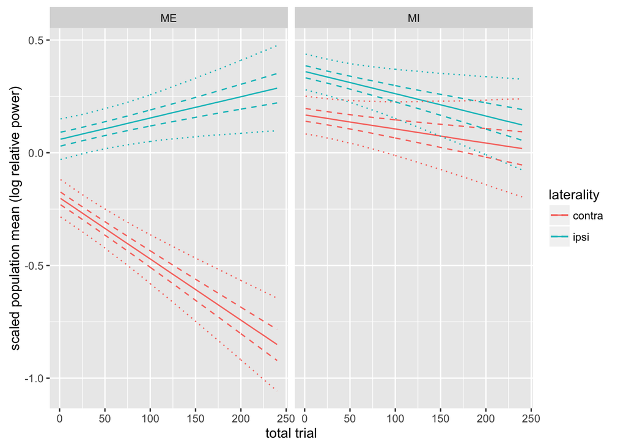

```r
cp = get_condition_post(
    from_stan = post_c
    , par = 'coefMpower'
    , W = W
    , B = B
    , collapse_intercept_to_median = T
)

cp %>%
    dplyr::group_by(
        task
        , trial
        , laterality
    ) %>%
    dplyr::summarise(
        med = median(value)
        , lo95 = quantile(value,.025)
        , hi95 = quantile(value,.975)
        , lo50 = quantile(value,.25)
        , hi50 = quantile(value,.75)
    ) %>%
    ggplot() +
  geom_line(aes(x=trial, y=med, color = laterality))+
  geom_line(aes(x=trial, y=hi95, color = laterality), linetype = "dotted")+
  geom_line(aes(x=trial, y=lo95, color = laterality), linetype = "dotted")+
  geom_line(aes(x=trial, y=hi50, color = laterality), linetype = "dashed")+
  geom_line(aes(x=trial, y=lo50, color = laterality), linetype = "dashed")+
    facet_grid(
        . ~ task
    )+
  xlab("total trial")+
  ylab("scaled population mean (log relative power)")
```

##### Log scaled ‘noise’

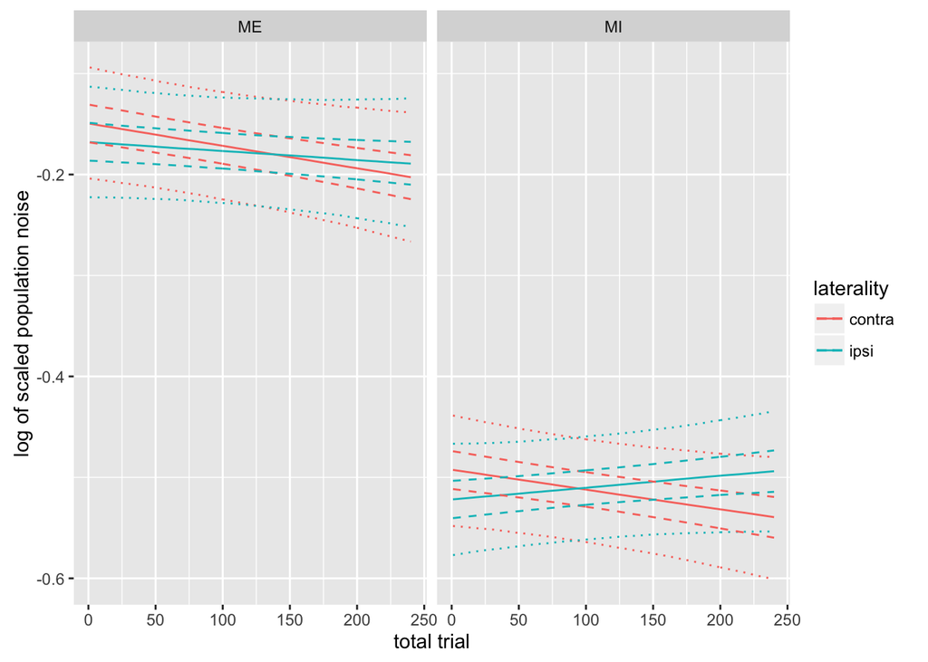

```r
cps = get_condition_post(
    from_stan = post_c
    , par = 'coefSpower'
    , W = W
    , B = B
    , collapse_intercept_to_median = T
)

cps %>%
    dplyr::group_by(
        task
        , trial
        , laterality
    ) %>%
    dplyr::summarise(
        med = median(value)
        , lo95 = quantile(value,.025)
        , hi95 = quantile(value,.975)
        , lo50 = quantile(value,.25)
        , hi50 = quantile(value,.75)
    ) %>%
    ggplot() +
  geom_line(aes(x=trial, y=med, color = laterality))+
  geom_line(aes(x=trial, y=hi95, color = laterality), linetype = "dotted")+
  geom_line(aes(x=trial, y=lo95, color = laterality), linetype = "dotted")+
  geom_line(aes(x=trial, y=hi50, color = laterality), linetype = "dashed")+
  geom_line(aes(x=trial, y=lo50, color = laterality), linetype = "dashed")+
    facet_grid(
        . ~ task
    ) +
  xlab("total trial")+
  ylab("log of scaled population noise")
```

### Unscaled output

##### ‘Power’ coefficients

The 95% credible intervals of the parameter estimates capture all the true population coefficients. This corroborates the findings from the 95% ‘null hypothesis’ approach to examining the effects we applied for the scaled coefficients.

```r
coefMpower = coefMpower_scaled[,1:3] * sd(dat$log_relative_power)
coefMpower[1,] = coefMpower[1,] + mean(dat$log_relative_power)
coefMpower
```

```
##                                 50%          2.5%         97.5%
## (I)                   -1.924958e-01 -0.2548238061 -1.312770e-01
## task                  -1.716646e-01 -0.2389488031 -1.037601e-01
## trial                 -4.340600e-04 -0.0008048542 -5.596998e-05
## laterality            -1.157529e-01 -0.1663580550 -6.653815e-02
## task:trial            -4.317422e-05 -0.0001935743  1.043184e-04
## task:laterality       -3.457787e-02 -0.0792951867  9.052060e-03
## trial:laterality      -8.499135e-04 -0.0011702620 -5.207346e-04
## task:trial:laterality -2.073502e-03 -0.0023145687 -1.815039e-03
```

##### Coefficient SDs

```r
sdsW = sdsW_scaled[,1:3] * sd(dat$log_relative_power)
# row.names(sdsW) = c(rep(row.names(coefMpower),1))
sdsW
```

```
##                                 50%          2.5%         97.5%
## (I)                   -1.710659e-01 -0.2001333807 -1.426399e-01
## task                   1.791346e-01  0.1275358773  2.315962e-01
## trial                 -4.978858e-05 -0.0001088255  1.062524e-05
## laterality             1.220582e-02 -0.0025590287  2.699176e-02
## task:trial            -5.943759e-05 -0.0001793602  6.090989e-05
## task:laterality       -5.687066e-03 -0.0363477869  2.503383e-02
## trial:laterality      -1.144351e-04 -0.0002211677 -9.369993e-06
## task:trial:laterality  9.114653e-05 -0.0001268607  3.098339e-04
```

### Condition Estimates

##### ‘Power’

These unsclaled graphs are virtually identical to those that are scaled. The difference is in the scale of the y-axis. Indeed, the credible intervals appear to capture the condition-wise means that were set (indirectly) in the creation of the data. Of course, the three-way interaction is particularly apparent (mainly because its effect size is so large).

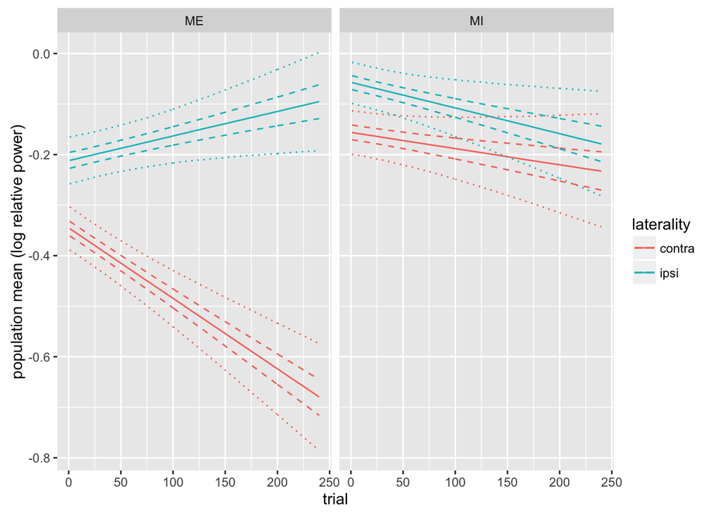

```r
SD = sd(dat$log_relative_power)
M = mean(dat$log_relative_power)

cp %>%
    dplyr::group_by(
        task
        , trial
        , laterality
    ) %>%
    dplyr::summarise(
        med = median(value) * SD + M
        , lo95 = quantile(value,.025) * SD + M
        , hi95 = quantile(value,.975) * SD + M
        , lo50 = quantile(value,.25) * SD + M
        , hi50 = quantile(value,.75) * SD + M
    ) %>%
    ggplot() +
  geom_line(aes(x=trial, y=med, color = laterality))+
  geom_line(aes(x=trial, y=hi95, color = laterality), linetype = "dotted")+
  geom_line(aes(x=trial, y=lo95, color = laterality), linetype = "dotted")+
  geom_line(aes(x=trial, y=hi50, color = laterality), linetype = "dashed")+
  geom_line(aes(x=trial, y=lo50, color = laterality), linetype = "dashed")+
    facet_grid(
        . ~ task
    )+
  ylab("population mean (log relative power)")
```

##### ‘Noise’

The model appears to caputre the population noise estimates extremely well (look at lognormal graphs from ‘create_data’).

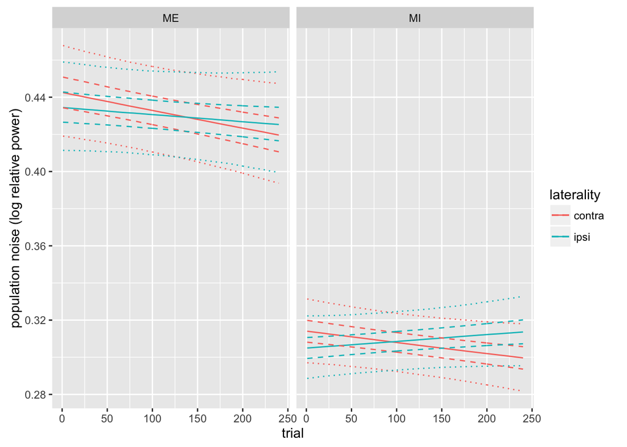

```r
cps %>%
    dplyr::group_by(
        task
        , trial
        , laterality
    ) %>%
    dplyr::summarise(
        med = exp(median(value)) * SD
        , lo95 = exp(quantile(value,.025)) * SD
        , hi95 = exp(quantile(value,.975)) * SD
        , lo50 = exp(quantile(value,.25)) * SD
        , hi50 = exp(quantile(value,.75)) * SD
    ) %>%
    ggplot() +
  geom_line(aes(x=trial, y=med, color = laterality))+
  geom_line(aes(x=trial, y=hi95, color = laterality), linetype = "dotted")+
  geom_line(aes(x=trial, y=lo95, color = laterality), linetype = "dotted")+
  geom_line(aes(x=trial, y=hi50, color = laterality), linetype = "dashed")+
  geom_line(aes(x=trial, y=lo50, color = laterality), linetype = "dashed")+
    facet_grid(
        . ~ task
    ) +
  ylab("population noise (log relative power)")
```

# Standard Statistics

Based on my knowledge of the neurofeedback litterature, multiple ANOVAs and/or pairwise comparisons are commonly used to analyse these data sets. I will do an analysis that I believe to be reasonably representative of what is done in the field.

### rANOVA

##### Get block means

We create a new column that categorizes the data into four blocks.

```r
for_aov2 = dat %>%
  mutate(
    block1 = ifelse(trial <= 60, 1, 0)
  ) %>%
  mutate(
    block2 = ifelse(trial <= 120 & trial > 60, 2, 0)
  ) %>%
  mutate(
    block3 = ifelse(trial <= 180 & trial > 120, 3, 0)
  ) %>%
  mutate(
    block4 = ifelse(trial <= 240 & trial > 180, 4, 0)
  ) %>%
  mutate(block = block1 + block2 + block3 + block4)
```

We average power over each block and get variances for each condition.

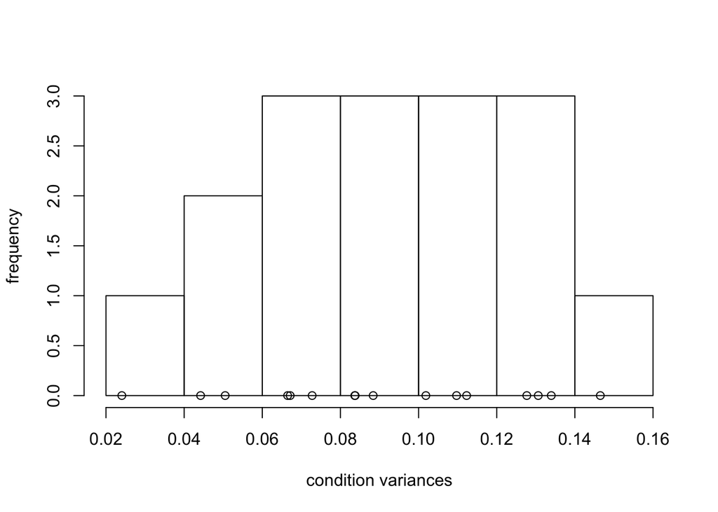

```r
for_aov = for_aov2 %>%
  group_by(subj, task, laterality, block) %>%
  summarize(mean_log_relative_power = mean(log_relative_power))

varz = for_aov %>%
  group_by(task, laterality, block) %>%
  summarize(varz = var(mean_log_relative_power))

hist(varz$varz, main = "", xlab = "condition variances", ylab = "frequency")
points(varz$varz, rep(0, length(varz$varz)))
```

```r
MSE = mean(varz$varz)
```

##### Run ezANOVA

The ezANOVA indicates that all true population effecs are detected, however an additional, spurious two-way interaction between task and laterality is detected.

```r
ezANOVA(
  as.data.frame(for_aov)
  , mean_log_relative_power
  , subj
  , .(task, laterality, block)
  , return_aov = T
  , detailed = T
)
```

```
## $ANOVA
##                  Effect DFn DFd         SSn       SSd           F
## 1                  task   1  39 4.939729632 6.1509022  31.3205200
## 2            laterality   1  39 7.630781719 3.0929803  96.2180339
## 3                 block   1  39 0.515243778 3.1218768   6.4366752
## 4       task:laterality   1  39 3.232961472 0.4229814 298.0875711
## 5            task:block   1  39 0.002505075 0.1237738   0.7893264
## 6      laterality:block   1  39 0.521182579 0.6847637  29.6834067
## 7 task:laterality:block   1  39 0.732277545 0.1272570 224.4185440
##              p p<.05         ges
## 1 1.881732e-06     * 0.264662425
## 2 4.404540e-12     * 0.357324675
## 3 1.529080e-02     * 0.036183411
## 4 7.306753e-20     * 0.190650867
## 5 3.797509e-01       0.000182492
## 6 3.019617e-06     * 0.036585210
## 7 9.114888e-18     * 0.050652765
##
## $aov
##
## Call:
## aov(formula = formula(aov_formula), data = data)
##
## Grand Mean: -0.2423347
##
## Stratum 1: subj
##
## Terms:
##                 Residuals
## Sum of Squares   41.86674
## Deg. of Freedom        39
##
## Residual standard error: 1.036101
##
## Stratum 2: subj:task
##
## Terms:
##                     task Residuals
## Sum of Squares  4.939730  6.150902
## Deg. of Freedom        1        39
```

[output cut: 63 more lines]

```
##                 task:laterality:block Residuals
## Sum of Squares              0.7322775 0.1272570
## Deg. of Freedom                     1        39
##
## Residual standard error: 0.05712267
## Estimated effects are balanced
##
## Stratum 9: Within
##
## Terms:
##                 Residuals
## Sum of Squares  0.7229836
## Deg. of Freedom       320
##
## Residual standard error: 0.04753234
```

### Parameter Estimates

We want to see whether the parameter estimates (95% CIs) capture the true population parameters.

##### Plot conditions

The plot does largely capture the trends set in the population during the data creation phase.

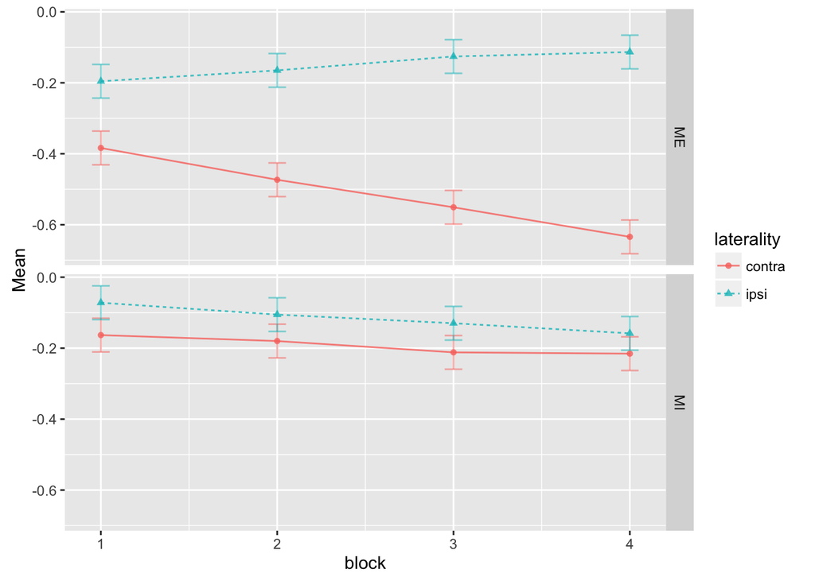

```r
ezPlot(
  as.data.frame(for_aov)
  , mean_log_relative_power
  , subj
  , .(task, laterality, block)
  , x = .(block)
  , row = .(task)
  , split = .(laterality)
  , bar_size = sqrt(MSE/40) * 2  # I get ~95% CIs, using the MSE associated with the main effect of block
  , bar_width = .1
  # , do_bars = F
)
```

##### Interaction effect

We start with the two-way interaction between task and laterality. We get an estimate for each block then average those. This is the false positive. The model is not even close to estimating this effect as being close to zero (the population value). NOTE: the sign might be flipped but I don’t care.

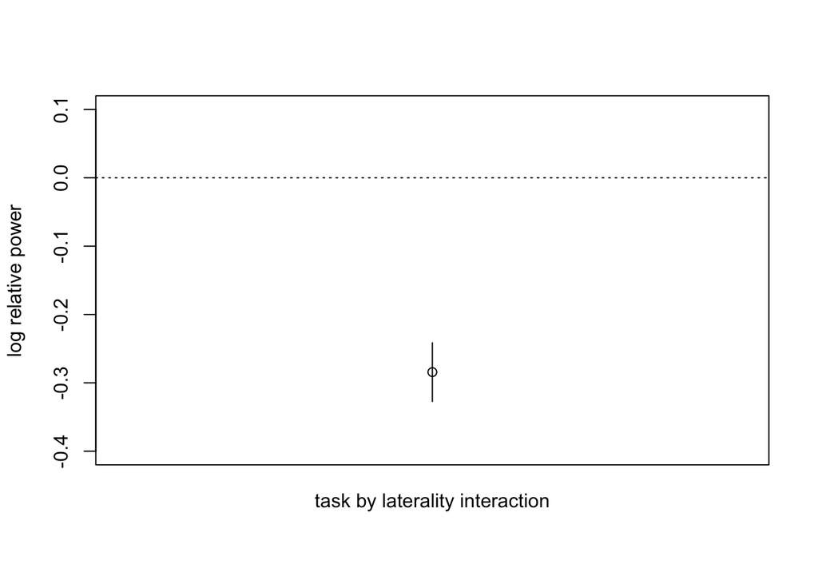

```r
lat_diffs = aggregate(mean_log_relative_power ~ task + block + subj, data=for_aov, FUN=diff)
lat_task_diffs = aggregate(mean_log_relative_power ~ block + subj, data=lat_diffs, FUN=diff)

two_ways_means = aggregate(mean_log_relative_power ~ block, data=lat_task_diffs, FUN=mean)
two_way_mean = mean(two_ways_means$mean_log_relative_power)

two_ways_vars = aggregate(mean_log_relative_power ~ block, data=lat_task_diffs, FUN=var)
two_way_var = mean(two_ways_vars$mean_log_relative_power)

plot(two_way_mean, ylab = "log relative power", xlab = "", xaxt = "n", ylim = c(-0.4, .1))
abline(h=0, lty = "dotted")
axis(1, 1, tick = F, labels = "task by laterality interaction")
segments(1, two_way_mean - 2*sqrt(two_way_var/40), 1, two_way_mean + 2*sqrt(two_way_var/40))
```

##### Laterality main effect

We get parameter estimates for the categorical main effects. The dotted red bar represents the true population mean. Therefore the traditional parameter estimate misses the effect despite correctly identifying that the effect is non-zero.

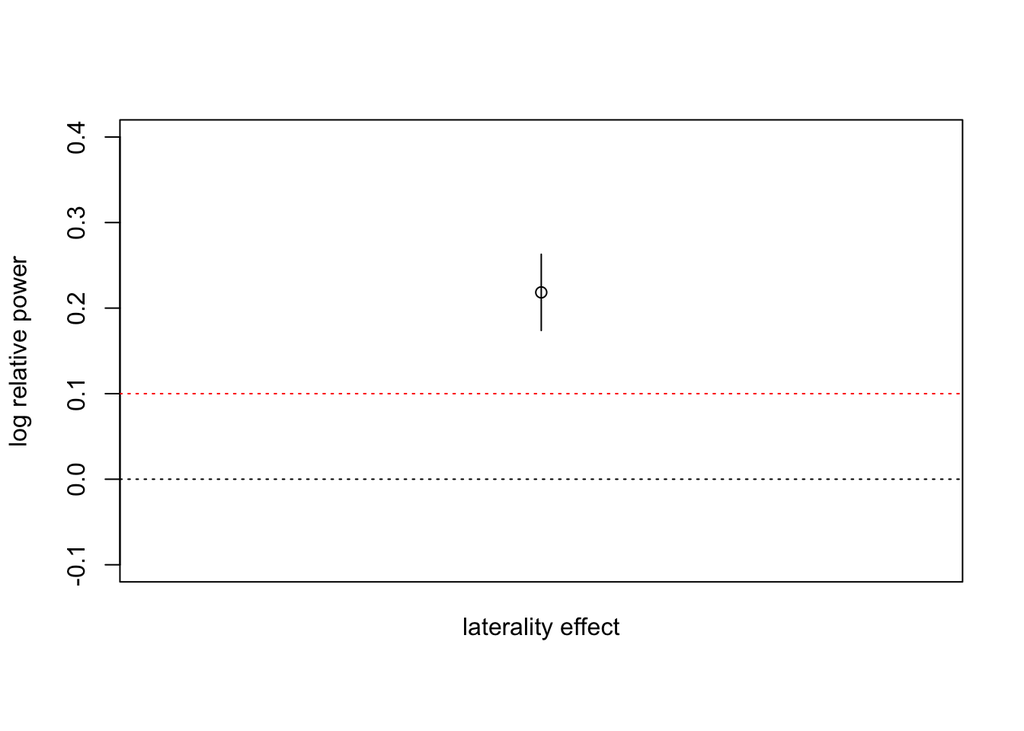

```r
lat_means = aggregate(mean_log_relative_power ~ laterality + subj, data=for_aov, FUN=mean)
lat_effects = aggregate(mean_log_relative_power ~ subj, data=lat_means, FUN=diff)
lat_effect = mean(lat_effects$mean_log_relative_power)
lat_var = var(lat_effects$mean_log_relative_power)

plot(lat_effect, ylab = "log relative power", xlab = "", xaxt = "n", ylim = c(-0.1, .4))
abline(h=0, lty = "dotted")
abline(h=.1, lty = "dotted", col = "red")
axis(1, 1, tick = F, labels = "laterality effect")
segments(1, lat_effect - 2*sqrt(lat_var/40), 1, lat_effect + 2*sqrt(lat_var/40))
```

##### Task main effect

The traditional parameter estimate does capture the true population effect of task.

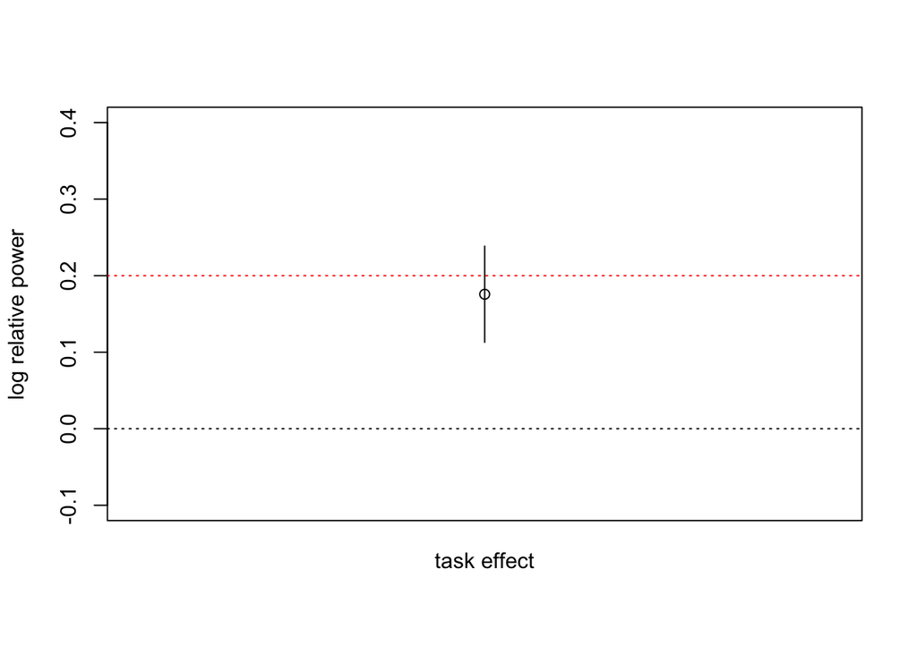

```r
task_means = aggregate(mean_log_relative_power ~ task + subj, data=for_aov, FUN=mean)
task_effects = aggregate(mean_log_relative_power ~ subj, data=task_means, FUN=diff)
task_effect = mean(task_effects$mean_log_relative_power)
task_var = var(task_effects$mean_log_relative_power)

plot(task_effect, ylab = "log relative power", xlab = "", xaxt = "n", ylim = c(-0.1, .4))
abline(h=0, lty = "dotted")
abline(h=.2, lty = "dotted", col = "red")
axis(1, 1, tick = F, labels = "task effect")
segments(1, task_effect - 2*sqrt(task_var/40), 1, task_effect + 2*sqrt(task_var/40))
```

### Shortcomings of Standard Analysis

As indicated in the previous demonstrations, estimates of the ‘power’ coefficients for all experimental effects were less precise than those calculated using the Bayesian analysis. Namely, a spurious result was detected by the rANOVA for the two-way interaction between task and laterality. Also, the frequentist parameter estimate did not capture the true main effect of laterality. We did not estimate any effects which included the trial factor since this factor was non-existant in the frequentist analysis. Instead, we calculated mean log relative power for each block and used that as a ‘time’ factor as that seems to be what is most common in the field. I’m assuming such a practice is common because it allows for the use of an ANOVA (as opposed to mulitple linear models or a mixed effect model) and facilitates interpretation.

Most researchers using rANOVA and subsequent traditional post-hoc tests or parameter estimates don’t get estimates for the standard deviations of the parameters of interest. They also don’t get estimates (or account) for the noise parameters I’ve included in the model.

I haven’t come across many studies examining correlations among the intercepts and condition effects (at least not in a comprehensive way). Further, as implied in the previous paragraph, researchers in the field don’t estimate the correlations among noise coefficients (or those coefficients and any other coefficients for that matter).

# Shortcomings of Simulation

We did all analyses on a single, putatively representative, sample because the Bayesian analysis takes nearly an entire day to run a Goodle Cloud Computer Engine. Ideally, the analyses presented herein would be conducted on multiple simulations to evalute the performance of these different analysis procedures in the long run (while accounting for random sampling).

We did all analyses on a sample from a single generative model. Ideally, we will vary the the population parameters of the generative model, covering a range of plausible values, to examine the performance of the different analysis approaches with respect to detecting a variety of effects and effect sizes.

The Bayesian analysis model assumed that the relationship between the outcome and trial (time) was linear. The generative model was created to meet this assumption. However, it is very plausible that in reality that training-related changes in brain activity follow non-linear pattern. Ideally, the Bayesian model would be constructed to account for arbitrary relationships between time and brain activity.